# Effect of forest condition on Pacific giant salamander populations

Allison Hacker and Cameryn Brock

11/20/2019

## Introduction

The Pacific giant salamander (*Dicamptodon tenebrosus*) is the largest amphibian species in the Pacific Northwest (Figure 1). Although not a threatened species, it is sensitive because it relies on cold, clean stream habitat for food and reproduction (“Pacific Giant Salamander” n.d.). Logging threatens this habitat by removing canopy cover and increasing soil erosion, which results in warmer water and increased suspended sediment. Due to their sensitivity to such environmental changes, amphibian populations can be used as an indicator of riparian ecosystem health (Welsh and Ollivier, 1998). Pacific giant salamander populations have been monitored in both clear cut and intact old growth forest in Oregon State’s H.J. Andrews Experimental Forest since 1993. In this study, we compare salamander abundance and weight in the two forest sections and various channel types to explore the effect of logging on salamander populations.

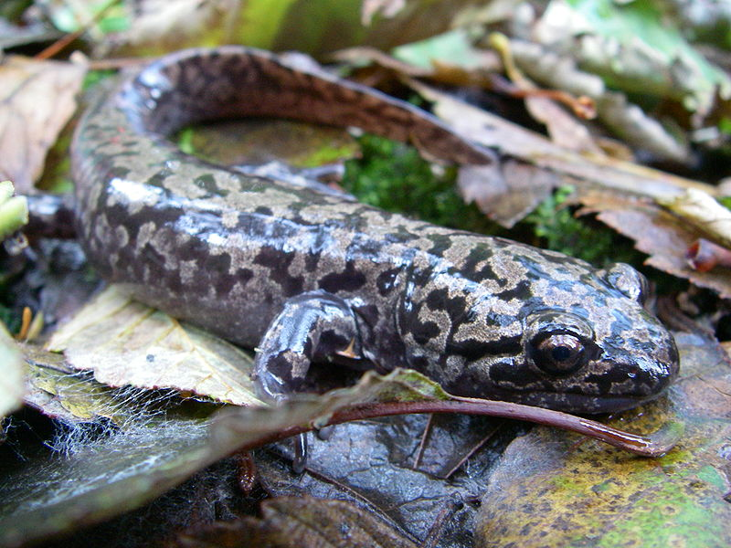

**Figure 1**. Pacific giant salamander (Dicamptodon tenebrosus). Credit: [Jeffery Marsten, Wikimedia](https://commons.wikimedia.org/wiki/File:Dicamptodon_tenebrosus_2.JPG)

## Data and methods

Pacific giant salamander data were provided by the [Aquatic Vertebrate Population Study](https://portal.lternet.edu/nis/mapbrowse?packageid=knb-lter-and.4027.12) in Mack Creek, Andrews Experimental Forest, Oregon (Gregory, 2016). Salamander abundance (individuals) and weight (grams) were determined by annual surveys in a section of clear cut forest (ca. 1963; clear cut) and a 500-year old coniferous forest (old growth). We explored information within three channel classifications: cascades, pools, and side channels. Data collection for Pacific giant salamanders began in 1993 and is ongoing.

Changes in salamander abundance from 1993 to 2017 were explored for each forest section. Abundance was analyzed for 2017 within each channel classification using a chi-square test for independence (alpha = 0.05 throughout). We analyzed differences in mean salamander weight within each forest section using a two-sample, two-sided t-test and within channel classifications with a one-way ANOVA and post-hoc Tukey’s HSD. R software (version 3.5.1) and RStudio (version 1.2.1335) were used for data analysis and figure generation.

## Results

### 1. Salamander abundance

#### 1a. Abundance in old growth and clear cut sections of Mack Creek

We analyzed changes in annual salamander abundance between 1993 and 2017 in clear cut and old growth forest (Figure 2).

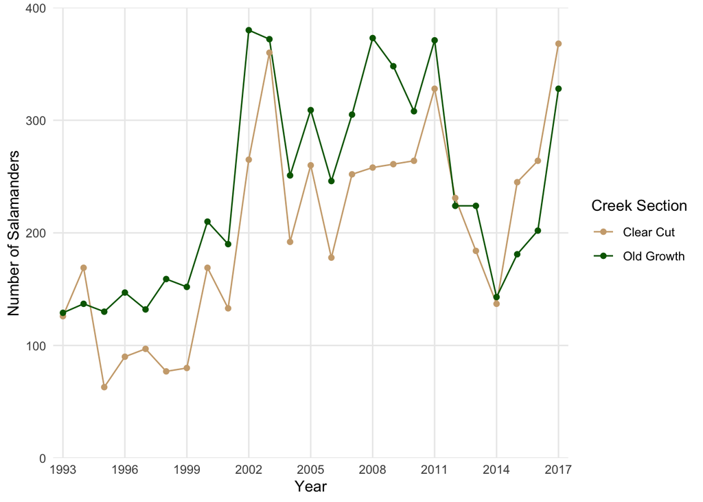

**Figure 2.** Pacific giant salamander abundance (1993-2017). The annual number of salamander observations is shown for an old growth coniferous forest (green) and a clear cut forest (brown) for all years that observations were recorded.

#### 1b. Abundance in different channel classifications in 2017

We analyzed salamander abundance among three different channel classifications (cascade, pool, and side channel) for both clear cut and old growth stream reaches in 2017 (Table 1).

**Table 1.** Pacific giant salamander abundance for different stream channel classifications in 2017. Number of observations and proportions are shown for clear cut and old growth sections of Mack Creek.

| Channel Classification | Clear Cut | Old Growth |
| --- | --- | --- |
| Cascade | 247 (67.1%) | 201 (62.8%) |
| Pool | 31 (8.4%) | 45 (14.1%) |
| Side Channel | 90 (24.5%) | 74 (23.1%) |

Salamander abundance differed among the three channel classifications. In both clear cut and old growth sections, cascades had the greatest number of salamanders ( 247 (67.1%) and 201 (62.8%), respectively), followed by side channels ( 90 (24.5%) and 74 (23.1%), respectively). Pools had the fewest number of salamanders for both clear cut and old growth sections ( 31 (8.4%) and 45 (14.1%), respectively).

However, there is no significant association between forest condition (clear cut and old growth) and the channel classification (cascade, pool, or side channel) where salamanders are found ($\chi^2$ (2) = 5.54, p = 0.063).

### 2. Salamander weight

#### 2a. Weight in clear cut and old growth in 2017

We analyzed salamander weights in old growth and clear cut sections of Mack Creek for 2017. Mean salamander weight in clear cut (7.78 ± 0.52, mean ± standard error, n = 368) and old growth (6.58 ± 0.49, n = 328) forest in 2017 did not differ significantly (two-sample, two-sided t-test, t(693) = 1.7, *p* = 0.096, Cohen’s d = 0.13).

#### 2b. Weight in different channel classifications in 2017

We compared salamander weights in 2017 in three different channel classifications: cascades, pools, and side channels (Figure 3).

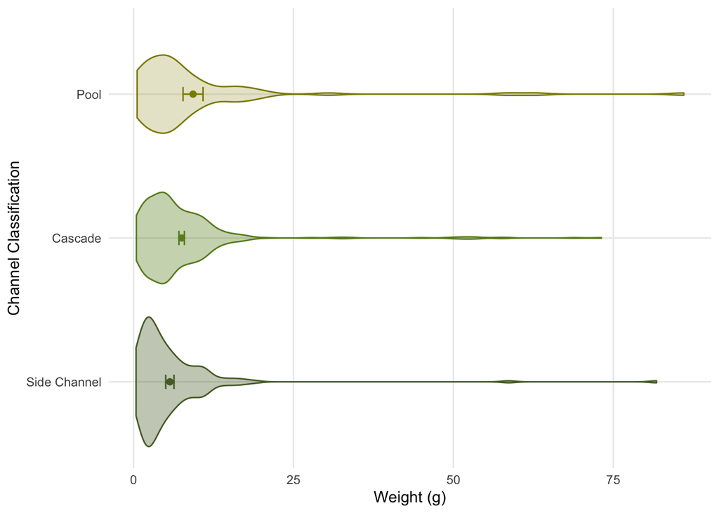

**Figure 3.** Pacific giant salamander weight within each channel classification in 2017. Error bars demonstrate the mean weight and standard error within each classification.

The mean weight for salamanders in side channels (5.68 ± 0.65g, mean ± standard error, n = 164) was lower than for those in cascades (7.52 ± 0.43g, n = 447) and pools (9.3 ± 1.56, n = 76). Mean salamander weight differed significantly between the three channel classifications (one-way ANOVA F(2, 684) = 4.22, *p* = 0.015). Pair-wise comparisons revealed that weights varied significantly between salamanders in side channels and in pools (post-hoc Tukey’s HSD, *p* = 0.017), but did not differ significantly between those in pools and cascades (*p* = 0.29) or between those in side channels and cascades (*p* = 0.084).

However, due to significant outliers, it is possible examining medians, rather than means, would be better for comparing salamander weights in this dataset. Alternative, non-parametric analyses such as Whitney-Mann (for two-sample analysis) and Kruskal-Wallis (for three-sample) should be explored.

### References

**Gregory S. V. 2016.** Aquatic Vertebrate Population Study in Mack Creek, Andrews Experimental Forest, 1987 to present. Environmental Data Initiative. https://doi.org/10.6073/pasta/5de64af9c11579266ef20da2ff32f702. Dataset accessed 11/30/2019.

**“Pacific Giant Salamander.” (n.d.).** Oregon Wild, oregonwild.org/wildlife/pacific-giant-salamander.

**Welsh, Hartwell H., Jr.; Ollivier, L.M. 1998.** Stream amphibians as indicators of ecosystem stress: a case study from California’’s redwoods. Ecological Applications 8(4):1118-1132